# Risk Factor Analysis

## Outcome Variable

**Outcome Variable:** stunted

## Predictor Variables

**Intervention Variable:** mage

**Adjustment Set:**

- arm
- meducyrs
- feducyrs
- hhwealth_quart
- W_mhtcm
- W_nrooms
- impfloor
- impsan
- safeh20
- delta_meducyrs
- delta_feducyrs
- delta_hhwealth_quart
- delta_W_mhtcm
- delta_W_nrooms
- delta_impfloor
- delta_impsan
- delta_safeh20

## Stratifying Variables

The analysis was stratified on these variable(s):

- agecat
- studyid
- country

## Data Summary

| agecat | studyid | country | mage | stunted | n_cell | n |
| --- | --- | --- | --- | --- | --- | --- |
| Birth | ki0047075b-MAL-ED | BANGLADESH | <25 | 0 | 97 | 257 |
| Birth | ki0047075b-MAL-ED | BANGLADESH | <25 | 1 | 23 | 257 |
| Birth | ki0047075b-MAL-ED | BANGLADESH | [25-30) | 0 | 77 | 257 |
| Birth | ki0047075b-MAL-ED | BANGLADESH | [25-30) | 1 | 15 | 257 |
| Birth | ki0047075b-MAL-ED | BANGLADESH | >=30 | 0 | 36 | 257 |
| Birth | ki0047075b-MAL-ED | BANGLADESH | >=30 | 1 | 9 | 257 |
| Birth | ki0047075b-MAL-ED | BRAZIL | <25 | 0 | 88 | 191 |
| Birth | ki0047075b-MAL-ED | BRAZIL | <25 | 1 | 9 | 191 |
| Birth | ki0047075b-MAL-ED | BRAZIL | [25-30) | 0 | 45 | 191 |
| Birth | ki0047075b-MAL-ED | BRAZIL | [25-30) | 1 | 9 | 191 |
| Birth | ki0047075b-MAL-ED | BRAZIL | >=30 | 0 | 37 | 191 |
| Birth | ki0047075b-MAL-ED | BRAZIL | >=30 | 1 | 3 | 191 |
| Birth | ki0047075b-MAL-ED | INDIA | <25 | 0 | 100 | 205 |
| Birth | ki0047075b-MAL-ED | INDIA | <25 | 1 | 22 | 205 |
| Birth | ki0047075b-MAL-ED | INDIA | [25-30) | 0 | 59 | 205 |
| Birth | ki0047075b-MAL-ED | INDIA | [25-30) | 1 | 9 | 205 |
| Birth | ki0047075b-MAL-ED | INDIA | >=30 | 0 | 14 | 205 |
| Birth | ki0047075b-MAL-ED | INDIA | >=30 | 1 | 1 | 205 |
| Birth | ki0047075b-MAL-ED | NEPAL | <25 | 0 | 40 | 173 |
| Birth | ki0047075b-MAL-ED | NEPAL | <25 | 1 | 6 | 173 |
| Birth | ki0047075b-MAL-ED | NEPAL | [25-30) | 0 | 83 | 173 |
| Birth | ki0047075b-MAL-ED | NEPAL | [25-30) | 1 | 8 | 173 |
| Birth | ki0047075b-MAL-ED | NEPAL | >=30 | 0 | 32 | 173 |
| Birth | ki0047075b-MAL-ED | NEPAL | >=30 | 1 | 4 | 173 |
| Birth | ki0047075b-MAL-ED | PERU | <25 | 0 | 139 | 287 |
| Birth | ki0047075b-MAL-ED | PERU | <25 | 1 | 22 | 287 |
| Birth | ki0047075b-MAL-ED | PERU | [25-30) | 0 | 57 | 287 |
| Birth | ki0047075b-MAL-ED | PERU | [25-30) | 1 | 4 | 287 |
| Birth | ki0047075b-MAL-ED | PERU | >=30 | 0 | 57 | 287 |
| Birth | ki0047075b-MAL-ED | PERU | >=30 | 1 | 8 | 287 |

[output cut: 378 more lines]

The following strata were considered:

- agecat: 24 months, studyid: ki0047075b-MAL-ED, country: BANGLADESH
- agecat: 24 months, studyid: ki0047075b-MAL-ED, country: BRAZIL
- agecat: 24 months, studyid: ki0047075b-MAL-ED, country: INDIA
- agecat: 24 months, studyid: ki0047075b-MAL-ED, country: NEPAL
- agecat: 24 months, studyid: ki0047075b-MAL-ED, country: PERU
- agecat: 24 months, studyid: ki0047075b-MAL-ED, country: SOUTH AFRICA
- agecat: 24 months, studyid: ki0047075b-MAL-ED, country: TANZANIA, UNITED REPUBLIC OF
- agecat: 24 months, studyid: ki1000108-CMC-V-BCS-2002, country: INDIA
- agecat: 24 months, studyid: ki1000108-IRC, country: INDIA
- agecat: 24 months, studyid: ki1017093-NIH-Birth, country: BANGLADESH
- agecat: 24 months, studyid: ki1017093b-PROVIDE, country: BANGLADESH
- agecat: 24 months, studyid: ki1017093c-NIH-Crypto, country: BANGLADESH
- agecat: 24 months, studyid: ki1066203-TanzaniaChild2, country: TANZANIA, UNITED REPUBLIC OF
- agecat: 24 months, studyid: ki1101329-Keneba, country: GAMBIA
- agecat: 24 months, studyid: ki1113344-GMS-Nepal, country: NEPAL
- agecat: 24 months, studyid: ki1119695-PROBIT, country: BELARUS
- agecat: 24 months, studyid: ki1126311-ZVITAMBO, country: ZIMBABWE
- agecat: 24 months, studyid: ki1135781-COHORTS, country: GUATEMALA
- agecat: 24 months, studyid: ki1135781-COHORTS, country: INDIA
- agecat: 24 months, studyid: ki1135781-COHORTS, country: PHILIPPINES
- agecat: 24 months, studyid: ki1148112-LCNI-5, country: MALAWI
- agecat: 24 months, studyid: kiGH5241-JiVitA-3, country: BANGLADESH
- agecat: 6 months, studyid: ki0047075b-MAL-ED, country: BANGLADESH
- agecat: 6 months, studyid: ki0047075b-MAL-ED, country: BRAZIL
- agecat: 6 months, studyid: ki0047075b-MAL-ED, country: INDIA
- agecat: 6 months, studyid: ki0047075b-MAL-ED, country: NEPAL
- agecat: 6 months, studyid: ki0047075b-MAL-ED, country: PERU
- agecat: 6 months, studyid: ki0047075b-MAL-ED, country: SOUTH AFRICA
- agecat: 6 months, studyid: ki0047075b-MAL-ED, country: TANZANIA, UNITED REPUBLIC OF
- agecat: 6 months, studyid: ki1000108-CMC-V-BCS-2002, country: INDIA
- agecat: 6 months, studyid: ki1000108-IRC, country: INDIA
- agecat: 6 months, studyid: ki1000109-EE, country: PAKISTAN
- agecat: 6 months, studyid: ki1000304b-SAS-CompFeed, country: INDIA
- agecat: 6 months, studyid: ki1000304b-SAS-FoodSuppl, country: INDIA
- agecat: 6 months, studyid: ki1017093-NIH-Birth, country: BANGLADESH
- agecat: 6 months, studyid: ki1017093b-PROVIDE, country: BANGLADESH
- agecat: 6 months, studyid: ki1017093c-NIH-Crypto, country: BANGLADESH
- agecat: 6 months, studyid: ki1066203-TanzaniaChild2, country: TANZANIA, UNITED REPUBLIC OF
- agecat: 6 months, studyid: ki1101329-Keneba, country: GAMBIA
- agecat: 6 months, studyid: ki1112895-Guatemala BSC, country: GUATEMALA
- agecat: 6 months, studyid: ki1113344-GMS-Nepal, country: NEPAL
- agecat: 6 months, studyid: ki1119695-PROBIT, country: BELARUS
- agecat: 6 months, studyid: ki1126311-ZVITAMBO, country: ZIMBABWE
- agecat: 6 months, studyid: ki1135781-COHORTS, country: GUATEMALA
- agecat: 6 months, studyid: ki1135781-COHORTS, country: INDIA
- agecat: 6 months, studyid: ki1135781-COHORTS, country: PHILIPPINES
- agecat: 6 months, studyid: ki1148112-LCNI-5, country: MALAWI
- agecat: 6 months, studyid: kiGH5241-JiVitA-3, country: BANGLADESH
- agecat: Birth, studyid: ki0047075b-MAL-ED, country: BANGLADESH
- agecat: Birth, studyid: ki0047075b-MAL-ED, country: BRAZIL
- agecat: Birth, studyid: ki0047075b-MAL-ED, country: INDIA
- agecat: Birth, studyid: ki0047075b-MAL-ED, country: NEPAL
- agecat: Birth, studyid: ki0047075b-MAL-ED, country: PERU
- agecat: Birth, studyid: ki0047075b-MAL-ED, country: SOUTH AFRICA
- agecat: Birth, studyid: ki0047075b-MAL-ED, country: TANZANIA, UNITED REPUBLIC OF
- agecat: Birth, studyid: ki1000108-CMC-V-BCS-2002, country: INDIA
- agecat: Birth, studyid: ki1000108-IRC, country: INDIA
- agecat: Birth, studyid: ki1000109-EE, country: PAKISTAN
- agecat: Birth, studyid: ki1000304b-SAS-CompFeed, country: INDIA
- agecat: Birth, studyid: ki1017093-NIH-Birth, country: BANGLADESH
- agecat: Birth, studyid: ki1017093c-NIH-Crypto, country: BANGLADESH
- agecat: Birth, studyid: ki1101329-Keneba, country: GAMBIA
- agecat: Birth, studyid: ki1119695-PROBIT, country: BELARUS
- agecat: Birth, studyid: ki1126311-ZVITAMBO, country: ZIMBABWE
- agecat: Birth, studyid: ki1135781-COHORTS, country: GUATEMALA
- agecat: Birth, studyid: ki1135781-COHORTS, country: INDIA
- agecat: Birth, studyid: ki1135781-COHORTS, country: PHILIPPINES
- agecat: Birth, studyid: kiGH5241-JiVitA-3, country: BANGLADESH

### Dropped Strata

Some strata were dropped due to rare outcomes:

- agecat: Birth, studyid: ki0047075b-MAL-ED, country: BRAZIL
- agecat: Birth, studyid: ki0047075b-MAL-ED, country: INDIA
- agecat: Birth, studyid: ki0047075b-MAL-ED, country: NEPAL
- agecat: Birth, studyid: ki0047075b-MAL-ED, country: PERU
- agecat: Birth, studyid: ki0047075b-MAL-ED, country: SOUTH AFRICA
- agecat: Birth, studyid: ki0047075b-MAL-ED, country: TANZANIA, UNITED REPUBLIC OF
- agecat: Birth, studyid: ki1000108-CMC-V-BCS-2002, country: INDIA
- agecat: Birth, studyid: ki1000108-IRC, country: INDIA
- agecat: Birth, studyid: ki1000109-EE, country: PAKISTAN
- agecat: Birth, studyid: ki1000304b-SAS-CompFeed, country: INDIA
- agecat: Birth, studyid: ki1017093-NIH-Birth, country: BANGLADESH
- agecat: Birth, studyid: ki1017093c-NIH-Crypto, country: BANGLADESH
- agecat: Birth, studyid: ki1119695-PROBIT, country: BELARUS
- agecat: 6 months, studyid: ki0047075b-MAL-ED, country: BRAZIL
- agecat: 6 months, studyid: ki0047075b-MAL-ED, country: INDIA
- agecat: 6 months, studyid: ki0047075b-MAL-ED, country: NEPAL
- agecat: 24 months, studyid: ki0047075b-MAL-ED, country: BRAZIL
- agecat: 24 months, studyid: ki0047075b-MAL-ED, country: INDIA
- agecat: 24 months, studyid: ki1066203-TanzaniaChild2, country: TANZANIA, UNITED REPUBLIC OF

## Methods Detail

We’re interested in the causal parameters $E[Y_a]$ for all values of $a \in \mathcal{A}$. These parameters represent the mean outcome if, possibly contrary to fact, we intervened to set all units to have $A=a$. Under the randomization and positivity assumptions, these are identified by the statistical parameters $\psi_a=E_W[E_{Y|A,W}(Y|A=a,W)]$. In addition, we’re interested in the mean of $Y$, $E[Y]$ under no intervention (the observed mean). We will estimate these parameters by using SuperLearner to fit the relevant likelihood factors – $E_{Y|A,W}(Y|A=a,W)$ and $p(A=a|W)$, and then updating our likelihood fit using a joint TMLE.

For unadjusted analyses ($W=\{\}$), initial likelihoods were estimated using Lrnr_glm to estimate the simple $E(Y|A)$ and Lrnr_mean to estimate $p(A)$. For adjusted analyses, a small library containing Lrnr_glmnet, Lrnr_xgboost, and Lrnr_mean was used.

Having estimated these parameters, we will then use the delta method to estimate relative risks and attributable risks relative to a prespecified baseline level of $A$.

# Results Detail

## Results Plots

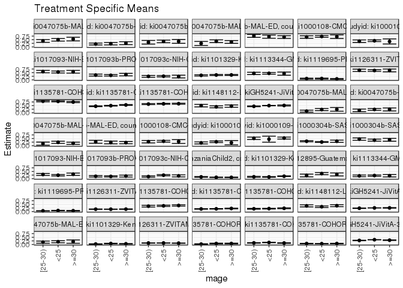

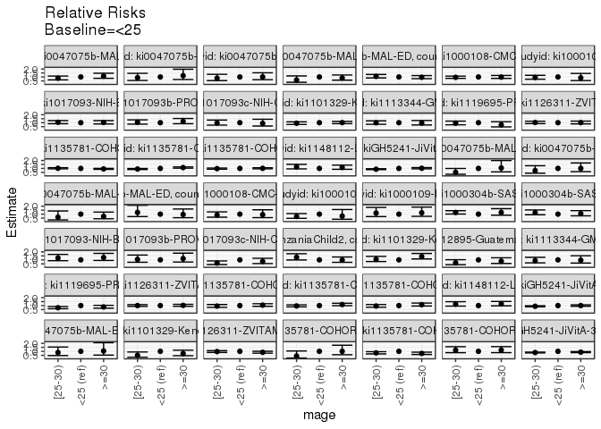

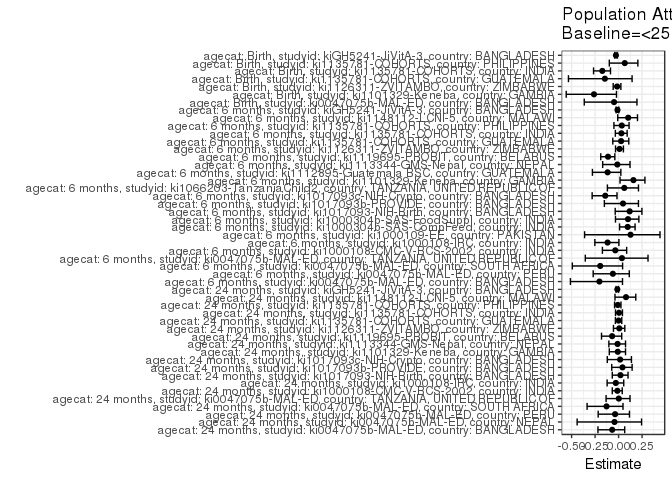

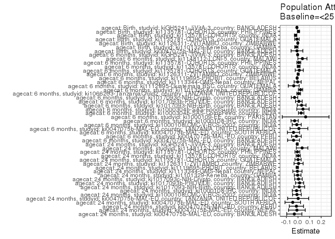

## Results Table

### Parameter: TSM

| agecat | studyid | country | intervention_level | baseline_level | estimate | ci_lower | ci_upper |
| --- | --- | --- | --- | --- | --- | --- | --- |
| Birth | ki0047075b-MAL-ED | BANGLADESH | <25 | NA | 0.1916667 | 0.1211044 | 0.2622289 |
| Birth | ki0047075b-MAL-ED | BANGLADESH | [25-30) | NA | 0.1630435 | 0.0874118 | 0.2386752 |
| Birth | ki0047075b-MAL-ED | BANGLADESH | >=30 | NA | 0.2000000 | 0.0829023 | 0.3170977 |
| Birth | ki1101329-Keneba | GAMBIA | <25 | NA | 0.0671402 | 0.0475795 | 0.0867008 |
| Birth | ki1101329-Keneba | GAMBIA | [25-30) | NA | 0.0324289 | 0.0139468 | 0.0509109 |
| Birth | ki1101329-Keneba | GAMBIA | >=30 | NA | 0.0482926 | 0.0308850 | 0.0657003 |
| Birth | ki1126311-ZVITAMBO | ZIMBABWE | <25 | NA | 0.1050335 | 0.0983705 | 0.1116964 |
| Birth | ki1126311-ZVITAMBO | ZIMBABWE | [25-30) | NA | 0.1014596 | 0.0915194 | 0.1113998 |
| Birth | ki1126311-ZVITAMBO | ZIMBABWE | >=30 | NA | 0.0922097 | 0.0807710 | 0.1036484 |
| Birth | ki1135781-COHORTS | GUATEMALA | <25 | NA | 0.0672515 | 0.0406918 | 0.0938112 |
| Birth | ki1135781-COHORTS | GUATEMALA | [25-30) | NA | 0.0271739 | 0.0036674 | 0.0506804 |
| Birth | ki1135781-COHORTS | GUATEMALA | >=30 | NA | 0.0674847 | 0.0402373 | 0.0947320 |
| Birth | ki1135781-COHORTS | INDIA | <25 | NA | 0.1387945 | 0.1240457 | 0.1535433 |
| Birth | ki1135781-COHORTS | INDIA | [25-30) | NA | 0.1111490 | 0.0958959 | 0.1264020 |
| Birth | ki1135781-COHORTS | INDIA | >=30 | NA | 0.1021020 | 0.0854487 | 0.1187553 |
| Birth | ki1135781-COHORTS | PHILIPPINES | <25 | NA | 0.0572940 | 0.0449950 | 0.0695930 |
| Birth | ki1135781-COHORTS | PHILIPPINES | [25-30) | NA | 0.0656727 | 0.0497271 | 0.0816184 |
| Birth | ki1135781-COHORTS | PHILIPPINES | >=30 | NA | 0.0660664 | 0.0500855 | 0.0820472 |
| Birth | kiGH5241-JiVitA-3 | BANGLADESH | <25 | NA | 0.3322946 | 0.3236273 | 0.3409618 |
| Birth | kiGH5241-JiVitA-3 | BANGLADESH | [25-30) | NA | 0.2811684 | 0.2647875 | 0.2975493 |
| Birth | kiGH5241-JiVitA-3 | BANGLADESH | >=30 | NA | 0.2982174 | 0.2775995 | 0.3188352 |
| 6 months | ki0047075b-MAL-ED | BANGLADESH | <25 | NA | 0.2248138 | 0.1496125 | 0.3000151 |
| 6 months | ki0047075b-MAL-ED | BANGLADESH | [25-30) | NA | 0.1143802 | 0.0476611 | 0.1810993 |
| 6 months | ki0047075b-MAL-ED | BANGLADESH | >=30 | NA | 0.2379178 | 0.1092198 | 0.3666158 |
| 6 months | ki0047075b-MAL-ED | PERU | <25 | NA | 0.2332083 | 0.1669648 | 0.2994518 |
| 6 months | ki0047075b-MAL-ED | PERU | [25-30) | NA | 0.1695800 | 0.0774445 | 0.2617156 |
| 6 months | ki0047075b-MAL-ED | PERU | >=30 | NA | 0.2333037 | 0.1300387 | 0.3365688 |
| 6 months | ki0047075b-MAL-ED | SOUTH AFRICA | <25 | NA | 0.2352941 | 0.1589309 | 0.3116573 |
| 6 months | ki0047075b-MAL-ED | SOUTH AFRICA | [25-30) | NA | 0.1463415 | 0.0379391 | 0.2547438 |
| 6 months | ki0047075b-MAL-ED | SOUTH AFRICA | >=30 | NA | 0.1702128 | 0.0940890 | 0.2463365 |

[output cut: 117 more lines]

### Parameter: E(Y)

| agecat | studyid | country | intervention_level | baseline_level | estimate | ci_lower | ci_upper |
| --- | --- | --- | --- | --- | --- | --- | --- |
| Birth | ki0047075b-MAL-ED | BANGLADESH | NA | NA | 0.1828794 | 0.1355257 | 0.2302330 |
| Birth | ki1101329-Keneba | GAMBIA | NA | NA | 0.0532122 | 0.0420018 | 0.0644226 |
| Birth | ki1126311-ZVITAMBO | ZIMBABWE | NA | NA | 0.1034083 | 0.0983260 | 0.1084905 |
| Birth | ki1135781-COHORTS | GUATEMALA | NA | NA | 0.0586854 | 0.0428942 | 0.0744767 |
| Birth | ki1135781-COHORTS | INDIA | NA | NA | 0.1183457 | 0.1091247 | 0.1275667 |
| Birth | ki1135781-COHORTS | PHILIPPINES | NA | NA | 0.0613115 | 0.0527962 | 0.0698268 |
| Birth | kiGH5241-JiVitA-3 | BANGLADESH | NA | NA | 0.3231138 | 0.3154608 | 0.3307668 |
| 6 months | ki0047075b-MAL-ED | BANGLADESH | NA | NA | 0.1867220 | 0.1374205 | 0.2360234 |
| 6 months | ki0047075b-MAL-ED | PERU | NA | NA | 0.2197802 | 0.1705687 | 0.2689917 |
| 6 months | ki0047075b-MAL-ED | SOUTH AFRICA | NA | NA | 0.1968504 | 0.1478551 | 0.2458457 |
| 6 months | ki0047075b-MAL-ED | TANZANIA, UNITED REPUBLIC OF | NA | NA | 0.2348178 | 0.1818480 | 0.2877876 |
| 6 months | ki1000108-CMC-V-BCS-2002 | INDIA | NA | NA | 0.3008130 | 0.2539566 | 0.3476694 |
| 6 months | ki1000108-IRC | INDIA | NA | NA | 0.2457002 | 0.2038248 | 0.2875757 |
| 6 months | ki1000109-EE | PAKISTAN | NA | NA | 0.5189189 | 0.4679396 | 0.5698982 |
| 6 months | ki1000304b-SAS-CompFeed | INDIA | NA | NA | 0.2844311 | 0.2666491 | 0.3022132 |
| 6 months | ki1000304b-SAS-FoodSuppl | INDIA | NA | NA | 0.4289474 | 0.3791199 | 0.4787748 |
| 6 months | ki1017093-NIH-Birth | BANGLADESH | NA | NA | 0.2672897 | 0.2297549 | 0.3048246 |
| 6 months | ki1017093b-PROVIDE | BANGLADESH | NA | NA | 0.1612350 | 0.1313580 | 0.1911120 |
| 6 months | ki1017093c-NIH-Crypto | BANGLADESH | NA | NA | 0.2097902 | 0.1799252 | 0.2396552 |
| 6 months | ki1066203-TanzaniaChild2 | TANZANIA, UNITED REPUBLIC OF | NA | NA | 0.0964215 | 0.0835208 | 0.1093221 |
| 6 months | ki1101329-Keneba | GAMBIA | NA | NA | 0.1408654 | 0.1259115 | 0.1558193 |
| 6 months | ki1112895-Guatemala BSC | GUATEMALA | NA | NA | 0.3115942 | 0.2568550 | 0.3663334 |
| 6 months | ki1113344-GMS-Nepal | NEPAL | NA | NA | 0.2113677 | 0.1776128 | 0.2451225 |
| 6 months | ki1119695-PROBIT | BELARUS | NA | NA | 0.0626864 | 0.0488489 | 0.0765239 |
| 6 months | ki1126311-ZVITAMBO | ZIMBABWE | NA | NA | 0.1660628 | 0.1580467 | 0.1740789 |
| 6 months | ki1135781-COHORTS | GUATEMALA | NA | NA | 0.4099896 | 0.3788775 | 0.4411017 |
| 6 months | ki1135781-COHORTS | INDIA | NA | NA | 0.1959625 | 0.1848518 | 0.2070732 |
| 6 months | ki1135781-COHORTS | PHILIPPINES | NA | NA | 0.2112260 | 0.1958496 | 0.2266024 |
| 6 months | ki1148112-LCNI-5 | MALAWI | NA | NA | 0.3736921 | 0.3370052 | 0.4103790 |
| 6 months | kiGH5241-JiVitA-3 | BANGLADESH | NA | NA | 0.2514524 | 0.2433306 | 0.2595742 |
| 24 months | ki0047075b-MAL-ED | BANGLADESH | NA | NA | 0.4622642 | 0.3949918 | 0.5295365 |
| 24 months | ki0047075b-MAL-ED | NEPAL | NA | NA | 0.2149123 | 0.1614774 | 0.2683472 |
| 24 months | ki0047075b-MAL-ED | PERU | NA | NA | 0.3681592 | 0.3013164 | 0.4350020 |
| 24 months | ki0047075b-MAL-ED | SOUTH AFRICA | NA | NA | 0.3529412 | 0.2921001 | 0.4137823 |
| 24 months | ki0047075b-MAL-ED | TANZANIA, UNITED REPUBLIC OF | NA | NA | 0.7149533 | 0.6543278 | 0.7755787 |
| 24 months | ki1000108-CMC-V-BCS-2002 | INDIA | NA | NA | 0.7150538 | 0.6691221 | 0.7609854 |
| 24 months | ki1000108-IRC | INDIA | NA | NA | 0.4156479 | 0.3678270 | 0.4634689 |
| 24 months | ki1017093-NIH-Birth | BANGLADESH | NA | NA | 0.5550351 | 0.5078433 | 0.6022269 |
| 24 months | ki1017093b-PROVIDE | BANGLADESH | NA | NA | 0.3292894 | 0.2909105 | 0.3676684 |
| 24 months | ki1017093c-NIH-Crypto | BANGLADESH | NA | NA | 0.2568093 | 0.2190047 | 0.2946140 |
| 24 months | ki1101329-Keneba | GAMBIA | NA | NA | 0.3348891 | 0.3125397 | 0.3572386 |
| 24 months | ki1113344-GMS-Nepal | NEPAL | NA | NA | 0.4468938 | 0.4032281 | 0.4905594 |
| 24 months | ki1119695-PROBIT | BELARUS | NA | NA | 0.0852540 | 0.0554439 | 0.1150642 |
| 24 months | ki1126311-ZVITAMBO | ZIMBABWE | NA | NA | 0.6535088 | 0.6097853 | 0.6972322 |
| 24 months | ki1135781-COHORTS | GUATEMALA | NA | NA | 0.7919400 | 0.7675726 | 0.8163075 |
| 24 months | ki1135781-COHORTS | INDIA | NA | NA | 0.4944520 | 0.4783291 | 0.5105749 |
| 24 months | ki1135781-COHORTS | PHILIPPINES | NA | NA | 0.6167689 | 0.5974942 | 0.6360437 |
| 24 months | ki1148112-LCNI-5 | MALAWI | NA | NA | 0.4505263 | 0.4057351 | 0.4953175 |
| 24 months | kiGH5241-JiVitA-3 | BANGLADESH | NA | NA | 0.4908806 | 0.4777422 | 0.5040189 |

### Parameter: RR

| agecat | studyid | country | intervention_level | baseline_level | estimate | ci_lower | ci_upper |
| --- | --- | --- | --- | --- | --- | --- | --- |
| Birth | ki0047075b-MAL-ED | BANGLADESH | <25 | <25 | 1.0000000 | 1.0000000 | 1.0000000 |
| Birth | ki0047075b-MAL-ED | BANGLADESH | [25-30) | <25 | 0.8506616 | 0.4705032 | 1.5379815 |
| Birth | ki0047075b-MAL-ED | BANGLADESH | >=30 | <25 | 1.0434783 | 0.5225389 | 2.0837624 |
| Birth | ki1101329-Keneba | GAMBIA | <25 | <25 | 1.0000000 | 1.0000000 | 1.0000000 |
| Birth | ki1101329-Keneba | GAMBIA | [25-30) | <25 | 0.4830023 | 0.2546726 | 0.9160435 |
| Birth | ki1101329-Keneba | GAMBIA | >=30 | <25 | 0.7192809 | 0.4526144 | 1.1430590 |
| Birth | ki1126311-ZVITAMBO | ZIMBABWE | <25 | <25 | 1.0000000 | 1.0000000 | 1.0000000 |
| Birth | ki1126311-ZVITAMBO | ZIMBABWE | [25-30) | <25 | 0.9659742 | 0.8596981 | 1.0853882 |
| Birth | ki1126311-ZVITAMBO | ZIMBABWE | >=30 | <25 | 0.8779075 | 0.7638327 | 1.0090188 |
| Birth | ki1135781-COHORTS | GUATEMALA | <25 | <25 | 1.0000000 | 1.0000000 | 1.0000000 |
| Birth | ki1135781-COHORTS | GUATEMALA | [25-30) | <25 | 0.4040643 | 0.1561233 | 1.0457624 |
| Birth | ki1135781-COHORTS | GUATEMALA | >=30 | <25 | 1.0034676 | 0.5704495 | 1.7651819 |
| Birth | ki1135781-COHORTS | INDIA | <25 | <25 | 1.0000000 | 1.0000000 | 1.0000000 |
| Birth | ki1135781-COHORTS | INDIA | [25-30) | <25 | 0.8008168 | 0.6733901 | 0.9523567 |
| Birth | ki1135781-COHORTS | INDIA | >=30 | <25 | 0.7356344 | 0.6056201 | 0.8935601 |
| Birth | ki1135781-COHORTS | PHILIPPINES | <25 | <25 | 1.0000000 | 1.0000000 | 1.0000000 |
| Birth | ki1135781-COHORTS | PHILIPPINES | [25-30) | <25 | 1.1462406 | 0.8299194 | 1.5831266 |
| Birth | ki1135781-COHORTS | PHILIPPINES | >=30 | <25 | 1.1531109 | 0.8357302 | 1.5910216 |
| Birth | kiGH5241-JiVitA-3 | BANGLADESH | <25 | <25 | 1.0000000 | 1.0000000 | 1.0000000 |
| Birth | kiGH5241-JiVitA-3 | BANGLADESH | [25-30) | <25 | 0.8461420 | 0.7957480 | 0.8997273 |
| Birth | kiGH5241-JiVitA-3 | BANGLADESH | >=30 | <25 | 0.8974488 | 0.8345601 | 0.9650765 |
| 6 months | ki0047075b-MAL-ED | BANGLADESH | <25 | <25 | 1.0000000 | 1.0000000 | 1.0000000 |
| 6 months | ki0047075b-MAL-ED | BANGLADESH | [25-30) | <25 | 0.5087776 | 0.2611113 | 0.9913573 |
| 6 months | ki0047075b-MAL-ED | BANGLADESH | >=30 | <25 | 1.0582883 | 0.5629783 | 1.9893734 |
| 6 months | ki0047075b-MAL-ED | PERU | <25 | <25 | 1.0000000 | 1.0000000 | 1.0000000 |
| 6 months | ki0047075b-MAL-ED | PERU | [25-30) | <25 | 0.7271612 | 0.3959860 | 1.3353083 |
| 6 months | ki0047075b-MAL-ED | PERU | >=30 | <25 | 1.0004091 | 0.5935950 | 1.6860287 |
| 6 months | ki0047075b-MAL-ED | SOUTH AFRICA | <25 | <25 | 1.0000000 | 1.0000000 | 1.0000000 |
| 6 months | ki0047075b-MAL-ED | SOUTH AFRICA | [25-30) | <25 | 0.6219512 | 0.2770327 | 1.3963091 |
| 6 months | ki0047075b-MAL-ED | SOUTH AFRICA | >=30 | <25 | 0.7234043 | 0.4162941 | 1.2570770 |

[output cut: 117 more lines]

### Parameter: PAR

| agecat | studyid | country | intervention_level | baseline_level | estimate | ci_lower | ci_upper |
| --- | --- | --- | --- | --- | --- | --- | --- |
| Birth | ki0047075b-MAL-ED | BANGLADESH | <25 | NA | -0.0087873 | -0.0594994 | 0.0419249 |
| Birth | ki1101329-Keneba | GAMBIA | <25 | NA | -0.0139280 | -0.0282354 | 0.0003795 |
| Birth | ki1126311-ZVITAMBO | ZIMBABWE | <25 | NA | -0.0016252 | -0.0058578 | 0.0026075 |
| Birth | ki1135781-COHORTS | GUATEMALA | <25 | NA | -0.0085660 | -0.0282754 | 0.0111434 |
| Birth | ki1135781-COHORTS | INDIA | <25 | NA | -0.0204488 | -0.0311401 | -0.0097575 |
| Birth | ki1135781-COHORTS | PHILIPPINES | <25 | NA | 0.0040174 | -0.0052671 | 0.0133020 |
| Birth | kiGH5241-JiVitA-3 | BANGLADESH | <25 | NA | -0.0091808 | -0.0133599 | -0.0050017 |
| 6 months | ki0047075b-MAL-ED | BANGLADESH | <25 | NA | -0.0380918 | -0.0895514 | 0.0133678 |
| 6 months | ki0047075b-MAL-ED | PERU | <25 | NA | -0.0134281 | -0.0554549 | 0.0285987 |
| 6 months | ki0047075b-MAL-ED | SOUTH AFRICA | <25 | NA | -0.0384437 | -0.0910542 | 0.0141668 |
| 6 months | ki0047075b-MAL-ED | TANZANIA, UNITED REPUBLIC OF | <25 | NA | 0.0083674 | -0.0684867 | 0.0852215 |
| 6 months | ki1000108-CMC-V-BCS-2002 | INDIA | <25 | NA | -0.0105760 | -0.0493419 | 0.0281899 |
| 6 months | ki1000108-IRC | INDIA | <25 | NA | -0.0288096 | -0.0603124 | 0.0026933 |
| 6 months | ki1000109-EE | PAKISTAN | <25 | NA | 0.0660804 | -0.1354704 | 0.2676313 |
| 6 months | ki1000304b-SAS-CompFeed | INDIA | <25 | NA | 0.0275254 | 0.0040514 | 0.0509995 |
| 6 months | ki1000304b-SAS-FoodSuppl | INDIA | <25 | NA | 0.0428965 | -0.0102443 | 0.0960374 |
| 6 months | ki1017093-NIH-Birth | BANGLADESH | <25 | NA | 0.0314299 | -0.0065180 | 0.0693779 |
| 6 months | ki1017093b-PROVIDE | BANGLADESH | <25 | NA | 0.0076022 | -0.0214682 | 0.0366727 |
| 6 months | ki1017093c-NIH-Crypto | BANGLADESH | <25 | NA | -0.0296934 | -0.0575158 | -0.0018709 |
| 6 months | ki1066203-TanzaniaChild2 | TANZANIA, UNITED REPUBLIC OF | <25 | NA | 0.0058646 | -0.0100101 | 0.0217393 |
| 6 months | ki1101329-Keneba | GAMBIA | <25 | NA | 0.0222954 | 0.0035601 | 0.0410306 |
| 6 months | ki1112895-Guatemala BSC | GUATEMALA | <25 | NA | -0.0364424 | -0.0833437 | 0.0104590 |
| 6 months | ki1113344-GMS-Nepal | NEPAL | <25 | NA | -0.0028524 | -0.0335090 | 0.0278042 |
| 6 months | ki1119695-PROBIT | BELARUS | <25 | NA | -0.0070372 | -0.0120658 | -0.0020086 |
| 6 months | ki1126311-ZVITAMBO | ZIMBABWE | <25 | NA | 0.0017202 | -0.0052550 | 0.0086954 |
| 6 months | ki1135781-COHORTS | GUATEMALA | <25 | NA | 0.0110951 | -0.0238013 | 0.0459916 |
| 6 months | ki1135781-COHORTS | INDIA | <25 | NA | 0.0059435 | -0.0063473 | 0.0182342 |
| 6 months | ki1135781-COHORTS | PHILIPPINES | <25 | NA | 0.0072489 | -0.0097386 | 0.0242363 |
| 6 months | ki1148112-LCNI-5 | MALAWI | <25 | NA | 0.0381897 | -0.0010690 | 0.0774484 |
| 6 months | kiGH5241-JiVitA-3 | BANGLADESH | <25 | NA | -0.0029406 | -0.0065206 | 0.0006393 |
| 24 months | ki0047075b-MAL-ED | BANGLADESH | <25 | NA | -0.0313680 | -0.0964830 | 0.0337470 |
| 24 months | ki0047075b-MAL-ED | NEPAL | <25 | NA | -0.0093078 | -0.0813864 | 0.0627709 |
| 24 months | ki0047075b-MAL-ED | PERU | <25 | NA | -0.0137158 | -0.0747922 | 0.0473606 |
| 24 months | ki0047075b-MAL-ED | SOUTH AFRICA | <25 | NA | -0.0452070 | -0.1122355 | 0.0218216 |
| 24 months | ki0047075b-MAL-ED | TANZANIA, UNITED REPUBLIC OF | <25 | NA | 0.0016904 | -0.0890697 | 0.0924505 |
| 24 months | ki1000108-CMC-V-BCS-2002 | INDIA | <25 | NA | -0.0091630 | -0.0470508 | 0.0287247 |
| 24 months | ki1000108-IRC | INDIA | <25 | NA | -0.0123676 | -0.0490431 | 0.0243078 |
| 24 months | ki1017093-NIH-Birth | BANGLADESH | <25 | NA | 0.0112664 | -0.0351183 | 0.0576512 |
| 24 months | ki1017093b-PROVIDE | BANGLADESH | <25 | NA | 0.0137215 | -0.0219136 | 0.0493565 |
| 24 months | ki1017093c-NIH-Crypto | BANGLADESH | <25 | NA | 0.0042708 | -0.0286748 | 0.0372163 |
| 24 months | ki1101329-Keneba | GAMBIA | <25 | NA | -0.0029574 | -0.0318400 | 0.0259253 |
| 24 months | ki1113344-GMS-Nepal | NEPAL | <25 | NA | -0.0048236 | -0.0443854 | 0.0347382 |
| 24 months | ki1119695-PROBIT | BELARUS | <25 | NA | -0.0058693 | -0.0153897 | 0.0036512 |
| 24 months | ki1126311-ZVITAMBO | ZIMBABWE | <25 | NA | 0.0049686 | -0.0344375 | 0.0443748 |
| 24 months | ki1135781-COHORTS | GUATEMALA | <25 | NA | 0.0004118 | -0.0263533 | 0.0271768 |
| 24 months | ki1135781-COHORTS | INDIA | <25 | NA | 0.0023882 | -0.0158724 | 0.0206487 |
| 24 months | ki1135781-COHORTS | PHILIPPINES | <25 | NA | -0.0049788 | -0.0259135 | 0.0159558 |
| 24 months | ki1148112-LCNI-5 | MALAWI | <25 | NA | 0.0355736 | -0.0141114 | 0.0852587 |
| 24 months | kiGH5241-JiVitA-3 | BANGLADESH | <25 | NA | -0.0066443 | -0.0131400 | -0.0001486 |

### Parameter: PAF

| agecat | studyid | country | intervention_level | baseline_level | estimate | ci_lower | ci_upper |
| --- | --- | --- | --- | --- | --- | --- | --- |
| Birth | ki0047075b-MAL-ED | BANGLADESH | <25 | NA | -0.0480496 | -0.3653006 | 0.1954826 |
| Birth | ki1101329-Keneba | GAMBIA | <25 | NA | -0.2617440 | -0.5572795 | -0.0222943 |
| Birth | ki1126311-ZVITAMBO | ZIMBABWE | <25 | NA | -0.0157162 | -0.0574790 | 0.0243973 |
| Birth | ki1135781-COHORTS | GUATEMALA | <25 | NA | -0.1459649 | -0.5335633 | 0.1436704 |
| Birth | ki1135781-COHORTS | INDIA | <25 | NA | -0.1727886 | -0.2664398 | -0.0860627 |
| Birth | ki1135781-COHORTS | PHILIPPINES | <25 | NA | 0.0655251 | -0.0986858 | 0.2051929 |
| Birth | kiGH5241-JiVitA-3 | BANGLADESH | <25 | NA | -0.0284134 | -0.0414564 | -0.0155338 |
| 6 months | ki0047075b-MAL-ED | BANGLADESH | <25 | NA | -0.2040028 | -0.5126126 | 0.0416430 |
| 6 months | ki0047075b-MAL-ED | PERU | <25 | NA | -0.0610979 | -0.2704267 | 0.1137396 |
| 6 months | ki0047075b-MAL-ED | SOUTH AFRICA | <25 | NA | -0.1952941 | -0.4924967 | 0.0427262 |
| 6 months | ki0047075b-MAL-ED | TANZANIA, UNITED REPUBLIC OF | <25 | NA | 0.0356337 | -0.3542358 | 0.3132640 |
| 6 months | ki1000108-CMC-V-BCS-2002 | INDIA | <25 | NA | -0.0351581 | -0.1723670 | 0.0859925 |
| 6 months | ki1000108-IRC | INDIA | <25 | NA | -0.1172549 | -0.2526423 | 0.0034996 |
| 6 months | ki1000109-EE | PAKISTAN | <25 | NA | 0.1273425 | -0.3619361 | 0.4408467 |
| 6 months | ki1000304b-SAS-CompFeed | INDIA | <25 | NA | 0.0967736 | 0.0104851 | 0.1755375 |
| 6 months | ki1000304b-SAS-FoodSuppl | INDIA | <25 | NA | 0.1000042 | -0.0329935 | 0.2158785 |
| 6 months | ki1017093-NIH-Birth | BANGLADESH | <25 | NA | 0.1175876 | -0.0359866 | 0.2483960 |
| 6 months | ki1017093b-PROVIDE | BANGLADESH | <25 | NA | 0.0471500 | -0.1513078 | 0.2113985 |
| 6 months | ki1017093c-NIH-Crypto | BANGLADESH | <25 | NA | -0.1415384 | -0.2814208 | -0.0169257 |
| 6 months | ki1066203-TanzaniaChild2 | TANZANIA, UNITED REPUBLIC OF | <25 | NA | 0.0608227 | -0.1188402 | 0.2116355 |
| 6 months | ki1101329-Keneba | GAMBIA | <25 | NA | 0.1582744 | 0.0153012 | 0.2804886 |
| 6 months | ki1112895-Guatemala BSC | GUATEMALA | <25 | NA | -0.1169546 | -0.2784655 | 0.0241523 |
| 6 months | ki1113344-GMS-Nepal | NEPAL | <25 | NA | -0.0134949 | -0.1694145 | 0.1216358 |
| 6 months | ki1119695-PROBIT | BELARUS | <25 | NA | -0.1122604 | -0.1896898 | -0.0398704 |
| 6 months | ki1126311-ZVITAMBO | ZIMBABWE | <25 | NA | 0.0103587 | -0.0325462 | 0.0514807 |
| 6 months | ki1135781-COHORTS | GUATEMALA | <25 | NA | 0.0270620 | -0.0617895 | 0.1084784 |
| 6 months | ki1135781-COHORTS | INDIA | <25 | NA | 0.0303297 | -0.0344443 | 0.0910477 |
| 6 months | ki1135781-COHORTS | PHILIPPINES | <25 | NA | 0.0343180 | -0.0495323 | 0.1114693 |
| 6 months | ki1148112-LCNI-5 | MALAWI | <25 | NA | 0.1021956 | -0.0091199 | 0.2012320 |
| 6 months | kiGH5241-JiVitA-3 | BANGLADESH | <25 | NA | -0.0116946 | -0.0260341 | 0.0024446 |
| 24 months | ki0047075b-MAL-ED | BANGLADESH | <25 | NA | -0.0678574 | -0.2196125 | 0.0650150 |
| 24 months | ki0047075b-MAL-ED | NEPAL | <25 | NA | -0.0433095 | -0.4411421 | 0.2446999 |
| 24 months | ki0047075b-MAL-ED | PERU | <25 | NA | -0.0372550 | -0.2170590 | 0.1159853 |
| 24 months | ki0047075b-MAL-ED | SOUTH AFRICA | <25 | NA | -0.1280864 | -0.3352730 | 0.0469522 |
| 24 months | ki0047075b-MAL-ED | TANZANIA, UNITED REPUBLIC OF | <25 | NA | 0.0023643 | -0.1330121 | 0.1215655 |
| 24 months | ki1000108-CMC-V-BCS-2002 | INDIA | <25 | NA | -0.0128145 | -0.0672344 | 0.0388305 |
| 24 months | ki1000108-IRC | INDIA | <25 | NA | -0.0297551 | -0.1219164 | 0.0548355 |
| 24 months | ki1017093-NIH-Birth | BANGLADESH | <25 | NA | 0.0202986 | -0.0670000 | 0.1004546 |
| 24 months | ki1017093b-PROVIDE | BANGLADESH | <25 | NA | 0.0416699 | -0.0728985 | 0.1440043 |
| 24 months | ki1017093c-NIH-Crypto | BANGLADESH | <25 | NA | 0.0166301 | -0.1203437 | 0.1368575 |
| 24 months | ki1101329-Keneba | GAMBIA | <25 | NA | -0.0088309 | -0.0988864 | 0.0738444 |
| 24 months | ki1113344-GMS-Nepal | NEPAL | <25 | NA | -0.0107935 | -0.1033253 | 0.0739779 |
| 24 months | ki1119695-PROBIT | BELARUS | <25 | NA | -0.0688446 | -0.1816498 | 0.0331918 |
| 24 months | ki1126311-ZVITAMBO | ZIMBABWE | <25 | NA | 0.0076030 | -0.0545723 | 0.0661126 |
| 24 months | ki1135781-COHORTS | GUATEMALA | <25 | NA | 0.0005199 | -0.0338539 | 0.0337509 |
| 24 months | ki1135781-COHORTS | INDIA | <25 | NA | 0.0048299 | -0.0327915 | 0.0410809 |
| 24 months | ki1135781-COHORTS | PHILIPPINES | <25 | NA | -0.0080725 | -0.0425997 | 0.0253114 |
| 24 months | ki1148112-LCNI-5 | MALAWI | <25 | NA | 0.0789601 | -0.0383420 | 0.1830106 |
| 24 months | kiGH5241-JiVitA-3 | BANGLADESH | <25 | NA | -0.0135355 | -0.0268497 | -0.0003938 |